# Assignment 3

#### Complete the code cells in this Jupyter notebook, and submit the final .ipynb notebook to Gradescope

##### Make sure you save your changes in VS Code before uploading it (beware of the little "dot" in the tab above)

##### You should **execute all code cells** before saving and submitting. We need to see the outputs/figures generated by Python

Import the numpy and matplotlib packages

```python
# Write your answer here
import numpy as np
import matplotlib.pyplot as plt
```

(a) Compute a Formula:

The formula for the volume of a cylinder is:

$V = \pi r^2 h$

Where:

- $V$ is the volume of the cylinder
- $r$ is the radius of the base
- $h$ is the height of the cylinder

Calculate $V$ when:

- $r = 4$
- $h = 12$

To get full points:

- Define each of these variables
- Use your variables to calculate the volume using the formula above
- Print out the result

```python
# Write your answer here
r = 4
h = 12
volume = np.pi * r**2 * h
print(volume)
```

```
603.1857894892403
```

(b) Operations on Arrays

- Define an array `temps_c` using `np.array()`, assigning the following values of temperatures measured in degrees Celsius:  
  `temps_c` $= \begin{pmatrix} c_1 \\ c_2 \\ c_3 \\ c_4 \\ c_5 \end{pmatrix} = \begin{pmatrix} 0 \\ 10 \\ 20 \\ 30 \\ 40 \end{pmatrix}$
- Use element-by-element vector operations to compute a new array `temps_f` of length 5, which will convert the temperatures from Celsius to Fahrenheit:  
  `temps_f` $= \begin{pmatrix} f_1 \\[8pt] f_2 \\[8pt] f_3 \\[8pt] f_4 \\[8pt] f_5 \end{pmatrix} = \begin{pmatrix} c_1 \times \tfrac{9}{5} +32 \\[8pt] c_2 \times \tfrac{9}{5} +32 \\[8pt] c_3 \times \tfrac{9}{5} + 32 \\[8pt] c_4 \times \tfrac{9}{5} + 32 \\[8pt] c_5 \times \tfrac{9}{5} + 32\end{pmatrix} $
- Print `temps_f`
- Compute and print the average of the Fahrenheit temperatures using `temps_f.mean()`
- To get full points you must do all of the above tasks

```python
# Write your answer here
temps_c = np.array([0, 10, 20, 30, 40])
temps_f = temps_c * 9/5 + 32
print(temps_f)
print(temps_f.mean())
```

```
[ 32.  50.  68.  86. 104.]
68.0
```

(c) Plot a Normal Random Variable

To get full points:

- Set the seed using `np.random.seed(1234)`
- Make the random variable with the following parameters:
  - mean = 7
  - standard deviation = 5
  - size = 1500
- Make a histogram
- Create a title
- Label the axes

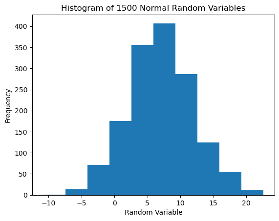

```python
# Write your answer here
np.random.seed(1234)
variable = np.random.normal(loc = 7, scale = 5, size = 1500)
plt.hist(x = variable)
plt.title("Histogram of 1500 Normal Random Variables")
plt.xlabel("Random Variable")
plt.ylabel("Frequency")
plt.show()
```

(d) Checking If a Word is Part of a List

- Define a variable `topping1` with the value "mushrooms"
- Define a variable `topping2` with the value "pineapple"
- Define a list of pizza toppings with the values "cheese", "mushrooms", "pepperoni", and "onions"
- Write expressions to test whether `topping1` and `topping2` are contained in `pizza_toppings`  
  and print the outputs
- To get full points you must do all of the above tasks

Hint: Use the "in" command. The final output should be 2 True/False values.

```python
# Write your answer here
topping1 = "mushrooms"
topping2 = "pineapple"
pizza_toppings = ["cheese", "mushrooms", "pepperoni", "onions"]
print(topping1 in pizza_toppings)
print(topping2 in pizza_toppings)
```

```
True
False
```

(e) Classifying a Variable

- Below, the variable `pizza_rating` is assigned a random value between 0 and 10
- Write an if/elif/else statement that does the following
  - `print("Best Pizza Ever")` if the rating is **greater than or equal to 9**.
  - `print("Pretty Good")` if the rating is **greater than or equal to 7 but less than 9**.
  - `print("Meh")` if the rating is **greater than or equal to 4 but less than 7**.
  - `print("Never Again")` otherwise.
- To get full points you must do all of the above tasks

```python
pizza_rating = np.random.uniform(low = 0, high = 10)

# Write your answer here
if pizza_rating >= 9:
    print("Best Pizza Ever")
elif 7 <= pizza_rating < 9:
    print("Pretty Good")
elif 4 <= pizza_rating < 7:
    print("Meh")
else:
    print("Never Again")
```

```
Meh
```